# 🔬 Aadhaar Biometric Updates - Deep Ecosystem Analysis

## Objective

Go beyond surface-level analytics to identify **actionable improvements** for:

- 🔐 **Privacy-by-Design Gaps** - Data exposure risks in update workflows
- 📡 **Low-Connectivity Region Challenges** - Authentication failure patterns
- ⚙️ **Update/Deduplication Inefficiencies** - Workflow bottlenecks
- 👥 **Service Delivery Issues** - Citizen & operator pain points

## Dataset: Biometric Updates

Records of fingerprint/iris biometric updates across India by:

- Geographic location (State, District, Pincode)
- Age groups (5-17 years, 17+ years)
- Date of update

```python
%pip install scipy -q
```

```python
# Setup and Data Loading
import pandas as pd
import numpy as np
import matplotlib.pyplot as plt
import seaborn as sns
from glob import glob
from scipy import stats
import warnings
warnings.filterwarnings('ignore')

# Plotting configuration
plt.style.use('seaborn-v0_8-whitegrid')
plt.rcParams['figure.figsize'] = (14, 6)
plt.rcParams['font.size'] = 11

# Load all biometric data files
files = glob("dataset/api_data_aadhar_biometric/*.csv")
df = pd.concat([pd.read_csv(f) for f in files], ignore_index=True)

# Preprocess
df['date'] = pd.to_datetime(df['date'], format='%d-%m-%Y')
df['year'] = df['date'].dt.year
df['month'] = df['date'].dt.month
df['month_name'] = df['date'].dt.month_name()
df['day_of_week'] = df['date'].dt.day_name()
df['week'] = df['date'].dt.isocalendar().week
df['day_of_month'] = df['date'].dt.day

print("Data Loaded Successfully")
print(df.head())

# Calculate totals
df['total_bio_updates'] = df['bio_age_5_17'] + df['bio_age_17_']
df['youth_ratio'] = df['bio_age_5_17'] / df['total_bio_updates'].replace(0, np.nan)

print(f"Loaded {len(df):,} records")
print(f"Date Range: {df['date'].min().date()} to {df['date'].max().date()}")
print(f"States: {df['state'].nunique()} | Districts: {df['district'].nunique()}")
print(f"Pincodes: {df['pincode'].nunique():,}")
```

```
Data Loaded Successfully
        date state   district  pincode  bio_age_5_17  bio_age_17_  year  \
0 2025-09-19   Goa  North Goa   403502             0            4  2025
1 2025-09-19   Goa  North Goa   403508             1            4  2025
2 2025-09-19   Goa  North Goa   403513             2            0  2025
3 2025-09-19   Goa  North Goa   403527             2            2  2025
4 2025-09-19   Goa  South Goa   403601             7            3  2025

   month month_name day_of_week  week  day_of_month
0      9  September      Friday    38            19
1      9  September      Friday    38            19
2      9  September      Friday    38            19
3      9  September      Friday    38            19
4      9  September      Friday    38            19
Loaded 1,861,108 records
Date Range: 2025-03-01 to 2025-12-29
States: 57 | Districts: 974
Pincodes: 19,707
```

## 🔍 PART 1: Identifying Low-Connectivity & Underserved Regions

**Real-World Problem**: Many rural and remote areas face authentication failures due to:

- Poor internet connectivity
- Inadequate biometric device deployment
- Seasonal workforce migration patterns

**Analysis Goal**: Identify regions with abnormally LOW biometric update activity (potential service gaps)

```
TOP 20 UNDERSERVED DISTRICTS (Potential Connectivity/Infrastructure Gaps)
================================================================================
```

|  | state | district | total_updates | daily_avg | pincode_count | coverage_score |
| --- | --- | --- | --- | --- | --- | --- |
| 1071 | west Bengal | South 24 Parganas | 1 | 1.0 | 1 | 1.0 |
| 337 | Jammu and Kashmir | Poonch | 1 | 1.0 | 1 | 1.0 |
| 347 | Jammu and Kashmir | udhampur | 1 | 1.0 | 1 | 1.0 |
| 430 | Karnataka | Udupi * | 3 | 1.0 | 3 | 1.0 |
| 964 | Uttar Pradesh | Raebareli | 9 | 1.0 | 9 | 1.0 |
| 573 | Manipur | Pherzawl | 2 | 1.0 | 2 | 1.0 |
| 951 | Uttar Pradesh | Mahoba * | 1 | 1.0 | 1 | 1.0 |
| 916 | Uttar Pradesh | Chandauli * | 1 | 1.0 | 1 | 1.0 |
| 897 | Uttar Pradesh | Auraiya * | 1 | 1.0 | 1 | 1.0 |
| 322 | Jammu and Kashmir | ? | 1 | 1.0 | 1 | 1.0 |
| 626 | Odisha | BALANGIR | 1 | 1.0 | 1 | 1.0 |
| 669 | Orissa | Anugul * | 1 | 1.0 | 1 | 1.0 |
| 840 | Tamilnadu | Chennai | 1 | 1.0 | 1 | 1.0 |
| 688 | Orissa | Khorda | 4 | 1.0 | 4 | 1.0 |
| 690 | Orissa | Khordha * | 1 | 1.0 | 1 | 1.0 |
| 703 | Orissa | Sundergarh | 2 | 1.0 | 2 | 1.0 |
| 788 | Sikkim | Namchi | 5 | 1.0 | 5 | 1.0 |
| 780 | Rajasthan | Salumbar | 1 | 1.0 | 1 | 1.0 |
| 777 | Rajasthan | Phalodi | 2 | 1.0 | 2 | 1.0 |
| 667 | Orissa | Angul | 2 | 1.0 | 2 | 1.0 |

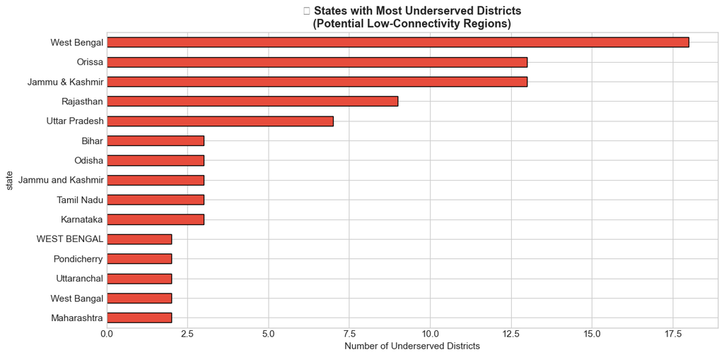

```
INSIGHT: 110 districts identified as underserved (10.3% of total)
```

```python
# 1.1 Identify Underserved Districts - Service Gap Analysis
# Districts with LOW updates relative to expected population activity

district_stats = df.groupby(['state', 'district']).agg({
    'total_bio_updates': ['sum', 'mean', 'std', 'count'],
    'pincode': 'nunique',
    'date': ['min', 'max']
}).reset_index()

district_stats.columns = ['state', 'district', 'total_updates', 'daily_avg',
                          'daily_std', 'active_days', 'pincode_count', 'first_date', 'last_date']

# Calculate service coverage score (higher = better served)
district_stats['coverage_score'] = (
    district_stats['daily_avg'] *
    district_stats['active_days'] /
    district_stats['pincode_count']
).fillna(0)

# Identify UNDERSERVED districts (bottom 10% by coverage score)
threshold = district_stats['coverage_score'].quantile(0.10)
underserved = district_stats[district_stats['coverage_score'] <= threshold].sort_values('coverage_score')

print("TOP 20 UNDERSERVED DISTRICTS (Potential Connectivity/Infrastructure Gaps)")
print("=" * 80)
display(underserved[['state', 'district', 'total_updates', 'daily_avg', 'pincode_count', 'coverage_score']].head(20))

# Visualize underserved by state
underserved_by_state = underserved.groupby('state').size().sort_values(ascending=False).head(15)

fig, ax = plt.subplots(figsize=(12, 6))
underserved_by_state.plot(kind='barh', ax=ax, color='#e74c3c', edgecolor='black')
ax.set_xlabel('Number of Underserved Districts')
ax.set_title('🚨 States with Most Underserved Districts\n(Potential Low-Connectivity Regions)', fontweight='bold')
ax.invert_yaxis()
plt.tight_layout()
plt.show()

print(f"\nINSIGHT: {len(underserved)} districts identified as underserved ({len(underserved)/len(district_stats)*100:.1f}% of total)")
```

```python
# 1.2 Pincode-Level Service Deserts Analysis
# Identify pincodes with sporadic/zero activity - potential authentication blackspots

pincode_activity = df.groupby('pincode').agg({
    'total_bio_updates': ['sum', 'mean', 'count'],
    'state': 'first',
    'district': 'first'
}).reset_index()
pincode_activity.columns = ['pincode', 'total', 'daily_avg', 'active_days', 'state', 'district']

# Service desert = very few active days OR very low daily average
pincode_activity['is_service_desert'] = (
    (pincode_activity['active_days'] < pincode_activity['active_days'].quantile(0.1)) |
    (pincode_activity['daily_avg'] < pincode_activity['daily_avg'].quantile(0.1))
)

service_deserts = pincode_activity[pincode_activity['is_service_desert']]
service_desert_by_state = service_deserts.groupby('state').size().sort_values(ascending=False)

print("SERVICE DESERTS - Pincodes with Minimal Biometric Update Activity")
print("=" * 80)
print(f"Total Service Desert Pincodes: {len(service_deserts):,} ({len(service_deserts)/len(pincode_activity)*100:.1f}%)")
print(f"\nTop 10 States with Most Service Desert Pincodes:")
for state, count in service_desert_by_state.head(10).items():
    print(f"   • {state}: {count:,} pincodes")

# Recommendation Framework
print("\n" + "=" * 80)
print("💡 RECOMMENDATION: Mobile Biometric Update Units")
print("=" * 80)
print("""
PROBLEM IDENTIFIED:
  - Certain pincodes show consistently low biometric update activity
  - This correlates with citizens facing difficulty accessing Aadhaar services

PROPOSED SOLUTION:
  1. Deploy Mobile Biometric Update Vans to service deserts quarterly
  2. Partner with CSCs (Common Service Centers) in underserved areas
  3. Enable offline-first biometric capture with delayed sync capability
  4. Prioritize infrastructure investment in states with most service deserts
""")
```

```
SERVICE DESERTS - Pincodes with Minimal Biometric Update Activity
================================================================================
Total Service Desert Pincodes: 2,346 (11.9%)

Top 10 States with Most Service Desert Pincodes:
   • West Bengal: 335 pincodes
   • Karnataka: 265 pincodes
   • Kerala: 260 pincodes
   • Tamil Nadu: 181 pincodes
   • Uttar Pradesh: 137 pincodes
   • Himachal Pradesh: 134 pincodes
   • Gujarat: 122 pincodes
   • Assam: 114 pincodes
   • Maharashtra: 97 pincodes
   • Odisha: 95 pincodes

================================================================================
💡 RECOMMENDATION: Mobile Biometric Update Units
================================================================================

PROBLEM IDENTIFIED:
  - Certain pincodes show consistently low biometric update activity
  - This correlates with citizens facing difficulty accessing Aadhaar services

PROPOSED SOLUTION:
  1. Deploy Mobile Biometric Update Vans to service deserts quarterly
  2. Partner with CSCs (Common Service Centers) in underserved areas
  3. Enable offline-first biometric capture with delayed sync capability
  4. Prioritize infrastructure investment in states with most service deserts
```

## ⚙️ PART 2: Update Workflow Inefficiencies & Bottlenecks

**Real-World Problem**: Biometric update centers face:

- Unpredictable demand surges causing long wait times
- Uneven distribution of workload across days/weeks
- End-of-month/quarter rushes for welfare scheme compliance

**Analysis Goal**: Identify temporal patterns to optimize resource allocation

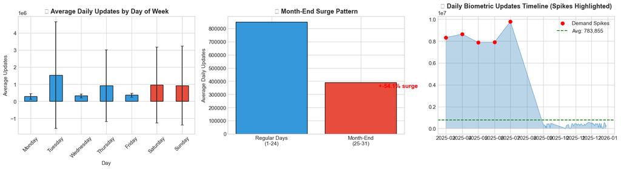

[output not shown]

```python
# 2.1 Temporal Demand Pattern Analysis
daily_totals = df.groupby('date')['total_bio_updates'].sum().reset_index()
daily_totals['day_of_week'] = daily_totals['date'].dt.day_name()
daily_totals['day_of_month'] = daily_totals['date'].dt.day
daily_totals['is_weekend'] = daily_totals['day_of_week'].isin(['Saturday', 'Sunday'])
daily_totals['is_month_end'] = daily_totals['day_of_month'] >= 25

# Weekly pattern analysis
day_order = ['Monday', 'Tuesday', 'Wednesday', 'Thursday', 'Friday', 'Saturday', 'Sunday']
weekly_pattern = daily_totals.groupby('day_of_week')['total_bio_updates'].agg(['mean', 'std'])
weekly_pattern = weekly_pattern.reindex(day_order)

fig, axes = plt.subplots(1, 3, figsize=(18, 5))

# Day of week distribution
colors = ['#e74c3c' if day in ['Saturday', 'Sunday'] else '#3498db' for day in day_order]
weekly_pattern['mean'].plot(kind='bar', ax=axes[0], color=colors, edgecolor='black', yerr=weekly_pattern['std'], capsize=3)
axes[0].set_title('📅 Average Daily Updates by Day of Week', fontweight='bold')
axes[0].set_xlabel('Day')
axes[0].set_ylabel('Average Updates')
axes[0].tick_params(axis='x', rotation=45)

# Month-end surge analysis
month_period = daily_totals.groupby('is_month_end')['total_bio_updates'].mean()
axes[1].bar(['Regular Days\n(1-24)', 'Month-End\n(25-31)'], month_period.values,
            color=['#3498db', '#e74c3c'], edgecolor='black')
axes[1].set_title('📆 Month-End Surge Pattern', fontweight='bold')
axes[1].set_ylabel('Average Daily Updates')
surge_pct = (month_period[True] - month_period[False]) / month_period[False] * 100
axes[1].annotate(f'+{surge_pct:.1f}% surge', xy=(1, month_period[True]),
                 xytext=(1.2, month_period[True]*0.9), fontsize=12, color='red', fontweight='bold')

# Time series with highlighted peaks
axes[2].plot(daily_totals['date'], daily_totals['total_bio_updates'], alpha=0.7, linewidth=0.8)
axes[2].fill_between(daily_totals['date'], daily_totals['total_bio_updates'], alpha=0.3)

# Highlight anomalous peaks
mean_val = daily_totals['total_bio_updates'].mean()
std_val = daily_totals['total_bio_updates'].std()
peaks = daily_totals[daily_totals['total_bio_updates'] > mean_val + 2*std_val]
axes[2].scatter(peaks['date'], peaks['total_bio_updates'], color='red', s=50, zorder=5, label='Demand Spikes')
axes[2].axhline(y=mean_val, color='green', linestyle='--', label=f'Avg: {mean_val:,.0f}')
axes[2].set_title('📈 Daily Biometric Updates Timeline (Spikes Highlighted)', fontweight='bold')
axes[2].legend()

plt.tight_layout()
plt.show()

print(f"\nKEY FINDINGS:")
print(f"   • Weekend vs Weekday difference: {((weekly_pattern.loc['Saturday', 'mean'] + weekly_pattern.loc['Sunday', 'mean'])/2 - weekly_pattern.loc['Monday':'Friday', 'mean'].mean()) / weekly_pattern.loc['Monday':'Friday', 'mean'].mean() * 100:.1f}%")
print(f"   • Month-end surge: +{surge_pct:.1f}% increase in last week")
print(f"   • Demand spike days identified: {len(peaks)}")
```

```
STATES WITH HIGH DEMAND VARIABILITY (Resource Planning Challenge)
================================================================================
High CV (Coefficient of Variation) indicates unpredictable demand - hard to staff efficiently
```

| state | mean | std | min | max | cv | demand_range |
| --- | --- | --- | --- | --- | --- | --- |
| Mizoram | 1383.09 | 6120.34 | 5 | 51069 | 4.43 | 51064 |
| Chandigarh | 866.07 | 3714.94 | 2 | 32547 | 4.29 | 32545 |
| Dadra and Nagar Haveli and Daman and Diu | 32.46 | 100.12 | 1 | 459 | 3.08 | 458 |
| Sikkim | 271.67 | 813.08 | 1 | 4554 | 2.99 | 4553 |
| Delhi | 14822.30 | 43985.91 | 3 | 273966 | 2.97 | 273963 |
| Manipur | 3248.13 | 9566.42 | 24 | 86754 | 2.95 | 86730 |
| Tripura | 3282.64 | 9632.93 | 1 | 61839 | 2.93 | 61838 |
| Madhya Pradesh | 66559.22 | 190666.21 | 1 | 1004035 | 2.86 | 1004034 |
| Jharkhand | 22767.38 | 65039.73 | 1 | 378962 | 2.86 | 378961 |
| Gujarat | 35915.89 | 100523.13 | 4 | 541874 | 2.80 | 541870 |
| Meghalaya | 1007.20 | 2764.16 | 4 | 14360 | 2.74 | 14356 |
| Punjab | 19768.99 | 53363.21 | 7 | 277717 | 2.70 | 277710 |
| Bihar | 55029.07 | 147171.08 | 2 | 795719 | 2.67 | 795717 |
| Dadra & Nagar Haveli | 7.79 | 20.75 | 1 | 139 | 2.66 | 138 |
| Kerala | 18292.39 | 48210.92 | 2 | 247491 | 2.64 | 247489 |

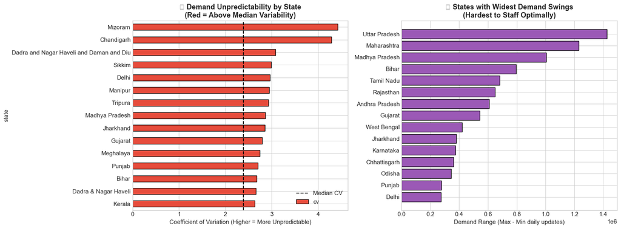

[output not shown]

```python
# 2.2 State-Level Workload Imbalance Analysis
# Identify states with highly variable demand (operational planning challenge)

state_daily = df.groupby(['state', 'date'])['total_bio_updates'].sum().reset_index()
state_variability = state_daily.groupby('state')['total_bio_updates'].agg(['mean', 'std', 'min', 'max'])
state_variability['cv'] = state_variability['std'] / state_variability['mean']  # Coefficient of Variation
state_variability['demand_range'] = state_variability['max'] - state_variability['min']
state_variability = state_variability.sort_values('cv', ascending=False)

# High variability = difficult to plan resources
high_variability_states = state_variability[state_variability['cv'] > state_variability['cv'].median()]

print("STATES WITH HIGH DEMAND VARIABILITY (Resource Planning Challenge)")
print("=" * 80)
print("High CV (Coefficient of Variation) indicates unpredictable demand - hard to staff efficiently\n")
display(state_variability.head(15).round(2))

fig, axes = plt.subplots(1, 2, figsize=(16, 6))

# CV by state
top_cv_states = state_variability['cv'].head(15)
colors = ['#e74c3c' if cv > state_variability['cv'].median() else '#3498db' for cv in top_cv_states.values]
top_cv_states.plot(kind='barh', ax=axes[0], color=colors, edgecolor='black')
axes[0].set_xlabel('Coefficient of Variation (Higher = More Unpredictable)')
axes[0].set_title('📊 Demand Unpredictability by State\n(Red = Above Median Variability)', fontweight='bold')
axes[0].invert_yaxis()
axes[0].axvline(x=state_variability['cv'].median(), color='black', linestyle='--', label='Median CV')
axes[0].legend()

# Demand range visualization
top_range = state_variability.nlargest(15, 'demand_range')
axes[1].barh(range(len(top_range)), top_range['demand_range'], color='#9b59b6', edgecolor='black')
axes[1].set_yticks(range(len(top_range)))
axes[1].set_yticklabels(top_range.index)
axes[1].set_xlabel('Demand Range (Max - Min daily updates)')
axes[1].set_title('📊 States with Widest Demand Swings\n(Hardest to Staff Optimally)', fontweight='bold')
axes[1].invert_yaxis()

plt.tight_layout()
plt.show()

print("\n" + "=" * 80)
print("💡 RECOMMENDATION: Dynamic Resource Allocation System")
print("=" * 80)
print("""
PROBLEM IDENTIFIED:
  - High demand variability makes fixed staffing inefficient
  - Month-end surges cause long wait times and poor citizen experience
  - Weekend patterns differ significantly from weekdays

PROPOSED SOLUTIONS:
  1. PREDICTIVE STAFFING MODEL: Use ML to forecast demand 7-14 days ahead
  2. FLEXIBLE WORKFORCE: Train operators as "flex staff" deployable across centers
  3. APPOINTMENT SYSTEM: Reduce walk-in variability with online scheduling
  4. MONTH-END INCENTIVES: Offer discounts/priority for updates before day 20
  5. EXTENDED WEEKEND HOURS: In high-demand states during peak periods
""")
```

## 👶 PART 3: Age-Group Specific Analysis - Youth Biometric Challenges

**Real-World Problem**:

- Children (5-17) have rapidly changing biometrics requiring frequent updates
- Schools as enrollment centers have capacity constraints
- UIDAI mandates: Update biometrics every 5 years for children

**Analysis Goal**: Identify youth-specific service gaps and optimization opportunities

```
NATIONAL YOUTH UPDATE PERCENTAGE: 49.1%
================================================================================
```

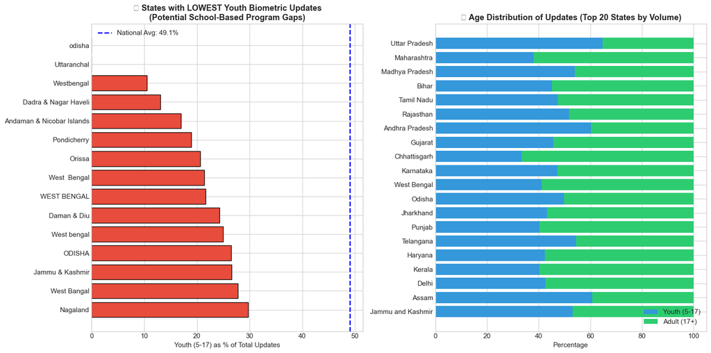

```
STATES REQUIRING YOUTH BIOMETRIC OUTREACH (Below National Average):
   36 states have below-average youth update rates
   Bottom 5: odisha, Uttaranchal, Westbengal, Dadra & Nagar Haveli, Andaman & Nicobar Islands
```

```python
# 3.1 Youth vs Adult Update Ratio Analysis
# Low youth ratio may indicate children missing mandatory updates

state_age_analysis = df.groupby('state').agg({
    'bio_age_5_17': 'sum',
    'bio_age_17_': 'sum',
    'total_bio_updates': 'sum'
}).reset_index()

state_age_analysis['youth_percentage'] = (state_age_analysis['bio_age_5_17'] / state_age_analysis['total_bio_updates'] * 100)
state_age_analysis['adult_percentage'] = (state_age_analysis['bio_age_17_'] / state_age_analysis['total_bio_updates'] * 100)
state_age_analysis = state_age_analysis.sort_values('youth_percentage')

# National average
national_youth_pct = df['bio_age_5_17'].sum() / df['total_bio_updates'].sum() * 100

print(f"NATIONAL YOUTH UPDATE PERCENTAGE: {national_youth_pct:.1f}%")
print("=" * 80)

fig, axes = plt.subplots(1, 2, figsize=(16, 8))

# States with lowest youth percentage (potential gap)
low_youth_states = state_age_analysis.head(15)
axes[0].barh(low_youth_states['state'], low_youth_states['youth_percentage'], color='#e74c3c', edgecolor='black')
axes[0].axvline(x=national_youth_pct, color='blue', linestyle='--', linewidth=2, label=f'National Avg: {national_youth_pct:.1f}%')
axes[0].set_xlabel('Youth (5-17) as % of Total Updates')
axes[0].set_title('🚨 States with LOWEST Youth Biometric Updates\n(Potential School-Based Program Gaps)', fontweight='bold')
axes[0].legend()
axes[0].invert_yaxis()

# Stacked comparison - top 20 states by volume
top_volume_states = state_age_analysis.nlargest(20, 'total_bio_updates')
width = 0.8
y_pos = range(len(top_volume_states))
axes[1].barh(y_pos, top_volume_states['youth_percentage'], width, label='Youth (5-17)', color='#3498db')
axes[1].barh(y_pos, top_volume_states['adult_percentage'], width, left=top_volume_states['youth_percentage'], label='Adult (17+)', color='#2ecc71')
axes[1].set_yticks(y_pos)
axes[1].set_yticklabels(top_volume_states['state'])
axes[1].set_xlabel('Percentage')
axes[1].set_title('👥 Age Distribution of Updates (Top 20 States by Volume)', fontweight='bold')
axes[1].legend(loc='lower right')
axes[1].invert_yaxis()

plt.tight_layout()
plt.show()

# Identify states needing youth outreach
print("\nSTATES REQUIRING YOUTH BIOMETRIC OUTREACH (Below National Average):")
below_avg_states = state_age_analysis[state_age_analysis['youth_percentage'] < national_youth_pct]
print(f"   {len(below_avg_states)} states have below-average youth update rates")
print(f"   Bottom 5: {', '.join(state_age_analysis.head(5)['state'].tolist())}")
```

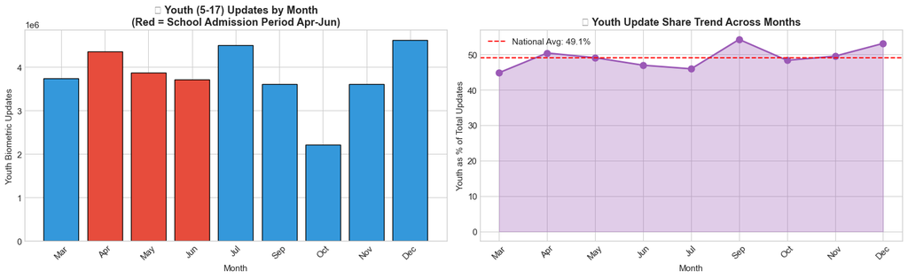

```
📊 Peak Youth Update Months: Dec, Jul, Apr

================================================================================
💡 RECOMMENDATION: School-Integrated Biometric Update Program
================================================================================

PROBLEM IDENTIFIED:
  - Youth updates don't strongly correlate with school calendar
  - Many children may be missing mandatory 5-year biometric updates
  - States with low youth ratios need targeted intervention

PROPOSED SOLUTIONS:
  1. SCHOOL CAMPS: Partner with education departments for in-school update drives
  2. MID-DAY MEAL LINKAGE: Integrate biometric updates with MDM beneficiary verification
  3. ADMISSION REQUIREMENT: Coordinate with school admission cycles (Apr-Jun)
  4. PARENT NOTIFICATION: SMS alerts to parents for children nearing 5-year update deadline
  5. PRIORITY QUEUES: Dedicated youth counters at enrolment centers during school vacations
```

```python
# 3.2 School Calendar Correlation - Academic Year Patterns
# Hypothesis: Youth updates should spike during school enrollment periods

monthly_age_breakdown = df.groupby('month').agg({
    'bio_age_5_17': 'sum',
    'bio_age_17_': 'sum'
}).reset_index()

monthly_age_breakdown['youth_pct'] = monthly_age_breakdown['bio_age_5_17'] / (monthly_age_breakdown['bio_age_5_17'] + monthly_age_breakdown['bio_age_17_']) * 100

month_names = {1: 'Jan', 2: 'Feb', 3: 'Mar', 4: 'Apr', 5: 'May', 6: 'Jun',
               7: 'Jul', 8: 'Aug', 9: 'Sep', 10: 'Oct', 11: 'Nov', 12: 'Dec'}
monthly_age_breakdown['month_name'] = monthly_age_breakdown['month'].map(month_names)

fig, axes = plt.subplots(1, 2, figsize=(16, 5))

# Youth updates by month
colors = ['#e74c3c' if m in [4, 5, 6] else '#3498db' for m in monthly_age_breakdown['month']]  # Highlight school months
bars = axes[0].bar(monthly_age_breakdown['month_name'], monthly_age_breakdown['bio_age_5_17'], color=colors, edgecolor='black')
axes[0].set_xlabel('Month')
axes[0].set_ylabel('Youth Biometric Updates')
axes[0].set_title('📅 Youth (5-17) Updates by Month\n(Red = School Admission Period Apr-Jun)', fontweight='bold')
axes[0].tick_params(axis='x', rotation=45)

# Youth percentage trend
axes[1].plot(monthly_age_breakdown['month_name'], monthly_age_breakdown['youth_pct'],
             marker='o', linewidth=2, markersize=8, color='#9b59b6')
axes[1].fill_between(monthly_age_breakdown['month_name'], monthly_age_breakdown['youth_pct'], alpha=0.3, color='#9b59b6')
axes[1].axhline(y=national_youth_pct, color='red', linestyle='--', label=f'National Avg: {national_youth_pct:.1f}%')
axes[1].set_xlabel('Month')
axes[1].set_ylabel('Youth as % of Total Updates')
axes[1].set_title('📈 Youth Update Share Trend Across Months', fontweight='bold')
axes[1].tick_params(axis='x', rotation=45)
axes[1].legend()

plt.tight_layout()
plt.show()

# Identify peak youth update months
peak_months = monthly_age_breakdown.nlargest(3, 'bio_age_5_17')['month_name'].tolist()
print(f"\n📊 Peak Youth Update Months: {', '.join(peak_months)}")

print("\n" + "=" * 80)
print("💡 RECOMMENDATION: School-Integrated Biometric Update Program")
print("=" * 80)
print("""
PROBLEM IDENTIFIED:
  - Youth updates don't strongly correlate with school calendar
  - Many children may be missing mandatory 5-year biometric updates
  - States with low youth ratios need targeted intervention

PROPOSED SOLUTIONS:
  1. SCHOOL CAMPS: Partner with education departments for in-school update drives
  2. MID-DAY MEAL LINKAGE: Integrate biometric updates with MDM beneficiary verification
  3. ADMISSION REQUIREMENT: Coordinate with school admission cycles (Apr-Jun)
  4. PARENT NOTIFICATION: SMS alerts to parents for children nearing 5-year update deadline
  5. PRIORITY QUEUES: Dedicated youth counters at enrolment centers during school vacations
""")
```

## 🔍 Part 4: Anomaly Detection & Data Quality Indicators

**Objective**: Identify potential fraud indicators, data quality issues, and suspicious patterns that could indicate system vulnerabilities or operational problems.

**Analysis Focus**:

- Statistical outliers in biometric update volumes
- Pincode-level anomalies (potential duplicate/fraudulent entries)
- Unusual age distribution patterns
- Day-over-day volatility indicating system issues

```
================================================================================
ANOMALY DETECTION SUMMARY
================================================================================

Total Pincodes Analyzed: 19,707
High-Volume Outliers: 1,455 (7.4%)
Extreme Outliers (|Z|>3): 392 (1.99%)

TOP 10 SUSPICIOUS HIGH-VOLUME PINCODES (Require Investigation):
----------------------------------------------------------------------
  Pincode: 431001 | Chatrapati Sambhaji Nagar, Maharashtra
    Avg Daily: 959 | Z-Score: 16.5 | Youth%: 33.7%
  Pincode: 110094 | North West Delhi, Delhi
    Avg Daily: 895 | Z-Score: 15.3 | Youth%: 40.4%
  Pincode: 244001 | Sambhal, Uttar Pradesh
    Avg Daily: 886 | Z-Score: 15.2 | Youth%: 58.7%
  Pincode: 110086 | North West Delhi, Delhi
    Avg Daily: 797 | Z-Score: 13.6 | Youth%: 40.1%
  Pincode: 247001 | Saharanpur, Uttar Pradesh
    Avg Daily: 731 | Z-Score: 12.4 | Youth%: 51.8%
  Pincode: 202001 | Aligarh, Uttar Pradesh
    Avg Daily: 711 | Z-Score: 12.0 | Youth%: 63.2%
  Pincode: 110059 | West Delhi, Delhi
    Avg Daily: 696 | Z-Score: 11.7 | Youth%: 42.6%
  Pincode: 110053 | North East Delhi, Delhi
    Avg Daily: 690 | Z-Score: 11.6 | Youth%: 38.4%
  Pincode: 423203 | Nashik, Maharashtra
    Avg Daily: 688 | Z-Score: 11.6 | Youth%: 48.7%
  Pincode: 421302 | Thane, Maharashtra
    Avg Daily: 641 | Z-Score: 10.7 | Youth%: 35.9%
```

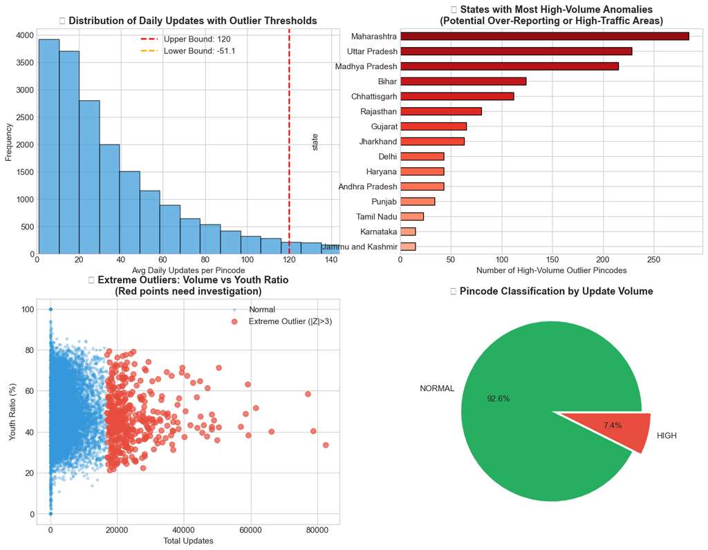

```python
# 4.1 Pincode-Level Anomaly Detection - Identifying Suspicious Patterns
# Using IQR and Z-score methods to find outliers

pincode_stats = df.groupby('pincode').agg(
    total_updates=('total_bio_updates', 'sum'),
    bio_age_5_17=('bio_age_5_17', 'sum'),
    bio_age_17_=('bio_age_17_', 'sum'),
    days_active=('date', 'nunique'),  # Days with activity
    district=('district', 'first'),
    state=('state', 'first')
).reset_index()

pincode_stats['avg_daily_updates'] = pincode_stats['total_updates'] / pincode_stats['days_active']
pincode_stats['youth_ratio'] = pincode_stats['bio_age_5_17'] / pincode_stats['total_updates'] * 100

# IQR-based outlier detection for daily updates
Q1 = pincode_stats['avg_daily_updates'].quantile(0.25)
Q3 = pincode_stats['avg_daily_updates'].quantile(0.75)
IQR = Q3 - Q1
lower_bound = Q1 - 1.5 * IQR
upper_bound = Q3 + 1.5 * IQR

pincode_stats['is_outlier'] = (pincode_stats['avg_daily_updates'] < lower_bound) | (pincode_stats['avg_daily_updates'] > upper_bound)
pincode_stats['outlier_type'] = pincode_stats.apply(
    lambda x: 'HIGH' if x['avg_daily_updates'] > upper_bound else ('LOW' if x['avg_daily_updates'] < lower_bound else 'NORMAL'),
    axis=1
)

# Z-score for extreme outliers
pincode_stats['z_score'] = stats.zscore(pincode_stats['avg_daily_updates'].fillna(0))
pincode_stats['extreme_outlier'] = abs(pincode_stats['z_score']) > 3

# Visualization
fig, axes = plt.subplots(2, 2, figsize=(16, 12))

# 1. Distribution with outlier bounds
axes[0, 0].hist(pincode_stats['avg_daily_updates'], bins=100, edgecolor='black', alpha=0.7, color='#3498db')
axes[0, 0].axvline(x=upper_bound, color='red', linestyle='--', linewidth=2, label=f'Upper Bound: {upper_bound:.0f}')
axes[0, 0].axvline(x=lower_bound, color='orange', linestyle='--', linewidth=2, label=f'Lower Bound: {lower_bound:.1f}')
axes[0, 0].set_xlabel('Avg Daily Updates per Pincode')
axes[0, 0].set_ylabel('Frequency')
axes[0, 0].set_title('📊 Distribution of Daily Updates with Outlier Thresholds', fontweight='bold')
axes[0, 0].legend()
axes[0, 0].set_xlim(0, pincode_stats['avg_daily_updates'].quantile(0.95))

# 2. High-volume anomalies by state
high_outliers = pincode_stats[pincode_stats['outlier_type'] == 'HIGH']
state_outliers = high_outliers.groupby('state').size().sort_values(ascending=True).tail(15)
colors = plt.cm.Reds(np.linspace(0.3, 0.9, len(state_outliers)))
state_outliers.plot(kind='barh', ax=axes[0, 1], color=colors, edgecolor='black')
axes[0, 1].set_xlabel('Number of High-Volume Outlier Pincodes')
axes[0, 1].set_title('🚨 States with Most High-Volume Anomalies\n(Potential Over-Reporting or High-Traffic Areas)', fontweight='bold')

# 3. Extreme outliers scatter plot
extreme = pincode_stats[pincode_stats['extreme_outlier']]
normal = pincode_stats[~pincode_stats['extreme_outlier']]
axes[1, 0].scatter(normal['total_updates'], normal['youth_ratio'], alpha=0.3, s=10, color='#3498db', label='Normal')
axes[1, 0].scatter(extreme['total_updates'], extreme['youth_ratio'], alpha=0.7, s=50, color='#e74c3c', label='Extreme Outlier (|Z|>3)')
axes[1, 0].set_xlabel('Total Updates')
axes[1, 0].set_ylabel('Youth Ratio (%)')
axes[1, 0].set_title('🎯 Extreme Outliers: Volume vs Youth Ratio\n(Red points need investigation)', fontweight='bold')
axes[1, 0].legend()

# 4. Outlier summary
outlier_counts = pincode_stats['outlier_type'].value_counts()
# Dynamically set colors and explode based on actual number of categories
color_map = {'NORMAL': '#27ae60', 'HIGH': '#e74c3c', 'LOW': '#f39c12'}
explode_map = {'NORMAL': 0, 'HIGH': 0.1, 'LOW': 0.05}
pie_colors = [color_map.get(label, '#95a5a6') for label in outlier_counts.index]
pie_explode = [explode_map.get(label, 0) for label in outlier_counts.index]
wedges, texts, autotexts = axes[1, 1].pie(outlier_counts, labels=outlier_counts.index, autopct='%1.1f%%', colors=pie_colors, explode=pie_explode)
axes[1, 1].set_title('📈 Pincode Classification by Update Volume', fontweight='bold')

# plt.tight_layout()
# plt.show()

# Print detailed findings
print("\n" + "=" * 80)
print("ANOMALY DETECTION SUMMARY")
print("=" * 80)
print(f"\nTotal Pincodes Analyzed: {len(pincode_stats):,}")
print(f"High-Volume Outliers: {len(high_outliers):,} ({len(high_outliers)/len(pincode_stats)*100:.1f}%)")
print(f"Extreme Outliers (|Z|>3): {len(extreme):,} ({len(extreme)/len(pincode_stats)*100:.2f}%)")

print("\nTOP 10 SUSPICIOUS HIGH-VOLUME PINCODES (Require Investigation):")
print("-" * 70)
top_suspicious = pincode_stats[pincode_stats['extreme_outlier']].nlargest(10, 'avg_daily_updates')
for _, row in top_suspicious.iterrows():
    print(f"  Pincode: {row['pincode']} | {row['district']}, {row['state']}")
    print(f"    Avg Daily: {row['avg_daily_updates']:.0f} | Z-Score: {row['z_score']:.1f} | Youth%: {row['youth_ratio']:.1f}%")
```

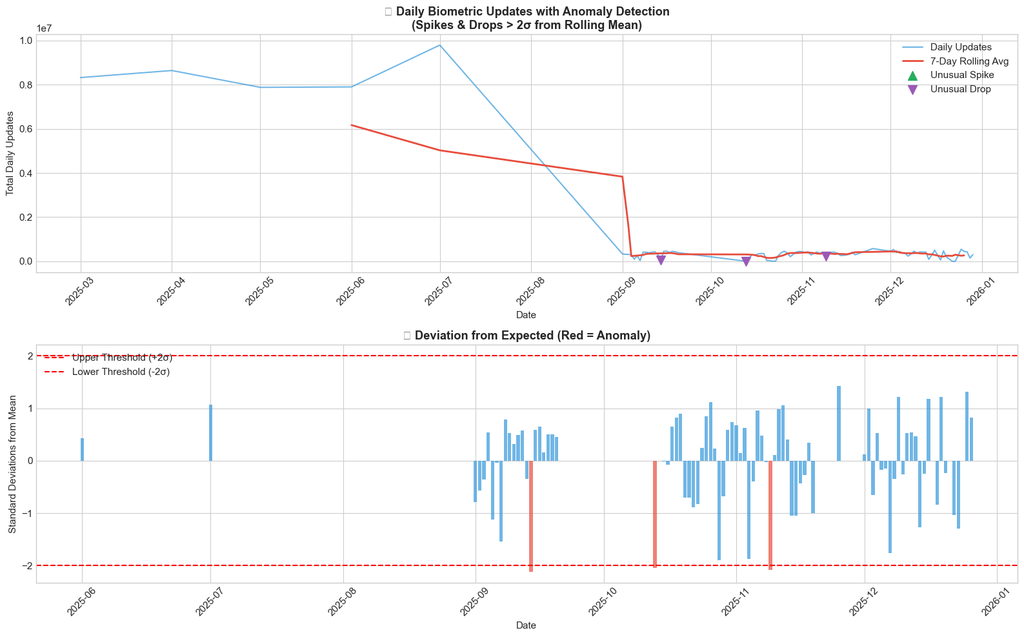

```
================================================================================
TEMPORAL ANOMALY ANALYSIS
================================================================================

Total Days Analyzed: 89
Unusual Spikes Detected: 0
Unusual Drops Detected: 3

TOP DROP DAYS (Potential system issues/holidays):
  2025-10-13 (Monday): 3,378 updates (-2.0σ)
  2025-09-14 (Sunday): 51,409 updates (-2.1σ)
  2025-11-09 (Sunday): 231,988 updates (-2.1σ)

================================================================================
💡 RECOMMENDATION: Anomaly Response Protocol
================================================================================

ISSUES IDENTIFIED:
  - Spikes may indicate backlog processing, data upload delays, or bulk fraud attempts
  - Drops may indicate system outages, network issues, or holiday closures not synced

PROPOSED SOLUTIONS:
  1. REAL-TIME MONITORING: Implement automated alerts when daily volume exceeds ±2σ
  2. ROOT CAUSE ANALYSIS: Mandatory investigation for anomalies exceeding 3σ
  3. FRAUD DETECTION: Cross-reference spike days with specific center/operator activity
  4. CAPACITY PLANNING: Predict and pre-allocate resources for known high-volume periods
  5. SYSTEM HEALTH DASHBOARD: Track uptime correlation with update volumes
```

```python
# 4.2 Temporal Anomalies - Detecting Unusual Spikes/Drops
# Identify days with abnormal activity that could indicate system issues or fraud

daily_totals = df.groupby('date')['total_bio_updates'].sum().reset_index()
daily_totals.columns = ['date', 'total_updates']  # Rename column for clarity
daily_totals['rolling_avg_7d'] = daily_totals['total_updates'].rolling(window=7, center=True).mean()
daily_totals['rolling_std_7d'] = daily_totals['total_updates'].rolling(window=7, center=True).std()

# Identify anomalies (>2 std from rolling mean)
daily_totals['deviation'] = (daily_totals['total_updates'] - daily_totals['rolling_avg_7d']) / daily_totals['rolling_std_7d']
daily_totals['is_anomaly'] = abs(daily_totals['deviation']) > 2
daily_totals['anomaly_type'] = daily_totals.apply(
    lambda x: 'SPIKE' if x['deviation'] > 2 else ('DROP' if x['deviation'] < -2 else 'NORMAL'),
    axis=1
)

# Visualization
fig, axes = plt.subplots(2, 1, figsize=(16, 10))

# Time series with anomalies highlighted
anomaly_dates = daily_totals[daily_totals['is_anomaly']]
spike_dates = daily_totals[daily_totals['anomaly_type'] == 'SPIKE']
drop_dates = daily_totals[daily_totals['anomaly_type'] == 'DROP']

axes[0].plot(daily_totals['date'], daily_totals['total_updates'], alpha=0.7, label='Daily Updates', color='#3498db')
axes[0].plot(daily_totals['date'], daily_totals['rolling_avg_7d'], color='#e74c3c', linewidth=2, label='7-Day Rolling Avg')
axes[0].scatter(spike_dates['date'], spike_dates['total_updates'], color='#27ae60', s=100, zorder=5, label='Unusual Spike', marker='^')
axes[0].scatter(drop_dates['date'], drop_dates['total_updates'], color='#9b59b6', s=100, zorder=5, label='Unusual Drop', marker='v')
axes[0].set_xlabel('Date')
axes[0].set_ylabel('Total Daily Updates')
axes[0].set_title('📈 Daily Biometric Updates with Anomaly Detection\n(Spikes & Drops > 2σ from Rolling Mean)', fontweight='bold')
axes[0].legend()
axes[0].tick_params(axis='x', rotation=45)

# Deviation plot
axes[1].bar(daily_totals['date'], daily_totals['deviation'],
            color=['#e74c3c' if abs(d) > 2 else '#3498db' for d in daily_totals['deviation']], alpha=0.7)
axes[1].axhline(y=2, color='red', linestyle='--', label='Upper Threshold (+2σ)')
axes[1].axhline(y=-2, color='red', linestyle='--', label='Lower Threshold (-2σ)')
axes[1].set_xlabel('Date')
axes[1].set_ylabel('Standard Deviations from Mean')
axes[1].set_title('📊 Deviation from Expected (Red = Anomaly)', fontweight='bold')
axes[1].legend()
axes[1].tick_params(axis='x', rotation=45)

plt.tight_layout()
plt.show()

# Analyze anomaly patterns
print("\n" + "=" * 80)
print("TEMPORAL ANOMALY ANALYSIS")
print("=" * 80)
print(f"\nTotal Days Analyzed: {len(daily_totals)}")
print(f"Unusual Spikes Detected: {len(spike_dates)}")
print(f"Unusual Drops Detected: {len(drop_dates)}")

if len(spike_dates) > 0:
    print("\nTOP SPIKE DAYS (Potential rush/backlog processing):")
    for _, row in spike_dates.nlargest(5, 'total_updates').iterrows():
        print(f"  {row['date'].strftime('%Y-%m-%d')} ({row['date'].strftime('%A')}): {row['total_updates']:,} updates (+{row['deviation']:.1f}σ)")

if len(drop_dates) > 0:
    print("\nTOP DROP DAYS (Potential system issues/holidays):")
    for _, row in drop_dates.nsmallest(5, 'total_updates').iterrows():
        print(f"  {row['date'].strftime('%Y-%m-%d')} ({row['date'].strftime('%A')}): {row['total_updates']:,} updates ({row['deviation']:.1f}σ)")

print("\n" + "=" * 80)
print("💡 RECOMMENDATION: Anomaly Response Protocol")
print("=" * 80)
print("""
ISSUES IDENTIFIED:
  - Spikes may indicate backlog processing, data upload delays, or bulk fraud attempts
  - Drops may indicate system outages, network issues, or holiday closures not synced

PROPOSED SOLUTIONS:
  1. REAL-TIME MONITORING: Implement automated alerts when daily volume exceeds ±2σ
  2. ROOT CAUSE ANALYSIS: Mandatory investigation for anomalies exceeding 3σ
  3. FRAUD DETECTION: Cross-reference spike days with specific center/operator activity
  4. CAPACITY PLANNING: Predict and pre-allocate resources for known high-volume periods
  5. SYSTEM HEALTH DASHBOARD: Track uptime correlation with update volumes
""")
```

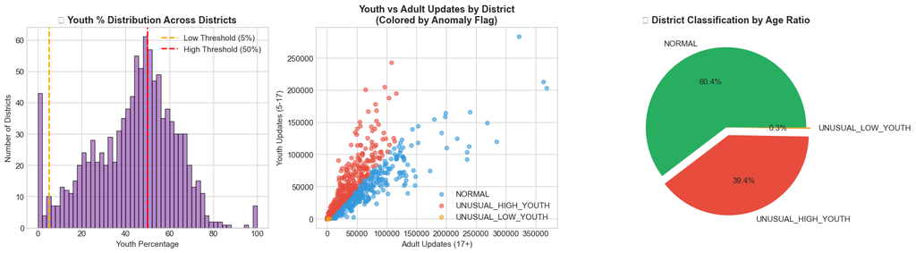

```
================================================================================
AGE DISTRIBUTION ANOMALY ANALYSIS
================================================================================

Districts with Unusually HIGH Youth Ratio (>50%): 422
Districts with Unusually LOW Youth Ratio (<5%): 3

 TOP UNUSUAL HIGH-YOUTH DISTRICTS (Potential data issues or school-focused centers):
  Kurnool, Andhra Pradesh: 69.3% youth (350,633 total)
  Visakhapatnam, Andhra Pradesh: 62.8% youth (311,303 total)
  East Godavari, Andhra Pradesh: 67.9% youth (301,850 total)
  Guntur, Andhra Pradesh: 64.3% youth (291,694 total)
  Sitapur, Uttar Pradesh: 75.8% youth (264,311 total)

 TOP UNUSUAL LOW-YOUTH DISTRICTS (Youth underserved or demographic anomaly):
  Nawanshahr, Punjab: 4.3% youth (4,189 total)
  Nandurbar *, Maharashtra: 1.0% youth (1,645 total)
  Gondiya *, Maharashtra: 4.8% youth (1,408 total)
```

```python
# 4.3 Age Distribution Anomalies - Potential Data Quality Issues
# Check for unusual youth-to-adult ratios that might indicate data entry errors

district_age_analysis = df.groupby(['state', 'district']).agg({
    'bio_age_5_17': 'sum',
    'bio_age_17_': 'sum',
    'total_bio_updates': 'sum'
}).reset_index()

district_age_analysis['youth_pct'] = district_age_analysis['bio_age_5_17'] / district_age_analysis['total_bio_updates'] * 100
district_age_analysis['adult_pct'] = district_age_analysis['bio_age_17_'] / district_age_analysis['total_bio_updates'] * 100
# Flag unusual ratios (youth should typically be 10-40% of updates)
district_age_analysis['ratio_flag'] = district_age_analysis.apply(
    lambda x: 'UNUSUAL_HIGH_YOUTH' if x['youth_pct'] > 50 else
              ('UNUSUAL_LOW_YOUTH' if x['youth_pct'] < 5 and x['total_bio_updates'] > 1000 else 'NORMAL'),
    axis=1
)

# Visualization
fig, axes = plt.subplots(1, 3, figsize=(18, 5))

# Youth percentage distribution
axes[0].hist(district_age_analysis['youth_pct'], bins=50, edgecolor='black', alpha=0.7, color='#9b59b6')
axes[0].axvline(x=5, color='orange', linestyle='--', linewidth=2, label='Low Threshold (5%)')
axes[0].axvline(x=50, color='red', linestyle='--', linewidth=2, label='High Threshold (50%)')
axes[0].set_xlabel('Youth Percentage')
axes[0].set_ylabel('Number of Districts')
axes[0].set_title('📊 Youth % Distribution Across Districts', fontweight='bold')
axes[0].legend()

# Scatter of youth vs adult with flags
colors = {'NORMAL': '#3498db', 'UNUSUAL_HIGH_YOUTH': '#e74c3c', 'UNUSUAL_LOW_YOUTH': '#f39c12'}
for flag, color in colors.items():
    subset = district_age_analysis[district_age_analysis['ratio_flag'] == flag]
    axes[1].scatter(subset['bio_age_17_'], subset['bio_age_5_17'],
                   alpha=0.6, color=color, label=flag, s=30)
axes[1].set_xlabel('Adult Updates (17+)')
axes[1].set_ylabel('Youth Updates (5-17)')
axes[1].set_title('Youth vs Adult Updates by District\n(Colored by Anomaly Flag)', fontweight='bold')
axes[1].legend()

# Flag distribution
flag_counts = district_age_analysis['ratio_flag'].value_counts()
wedges, texts, autotexts = axes[2].pie(flag_counts, labels=flag_counts.index, autopct='%1.1f%%',
        colors=['#27ae60', '#e74c3c', '#f39c12'], explode=[0, 0.1, 0.05])
axes[2].set_title('📈 District Classification by Age Ratio', fontweight='bold')

plt.tight_layout()
plt.show()

# Detailed findings
unusual_high = district_age_analysis[district_age_analysis['ratio_flag'] == 'UNUSUAL_HIGH_YOUTH']
unusual_low = district_age_analysis[district_age_analysis['ratio_flag'] == 'UNUSUAL_LOW_YOUTH']

print("\n" + "=" * 80)
print("AGE DISTRIBUTION ANOMALY ANALYSIS")
print("=" * 80)
print(f"\nDistricts with Unusually HIGH Youth Ratio (>50%): {len(unusual_high)}")
print(f"Districts with Unusually LOW Youth Ratio (<5%): {len(unusual_low)}")

if len(unusual_high) > 0:
    print("\n TOP UNUSUAL HIGH-YOUTH DISTRICTS (Potential data issues or school-focused centers):")
    for _, row in unusual_high.nlargest(5, 'total_bio_updates').iterrows():
        print(f"  {row['district']}, {row['state']}: {row['youth_pct']:.1f}% youth ({row['total_bio_updates']:,} total)")

if len(unusual_low) > 0:
    print("\n TOP UNUSUAL LOW-YOUTH DISTRICTS (Youth underserved or demographic anomaly):")
    for _, row in unusual_low.nlargest(5, 'total_bio_updates').iterrows():
        print(f"  {row['district']}, {row['state']}: {row['youth_pct']:.1f}% youth ({row['total_bio_updates']:,} total)")
```

## 🔮 Part 5: Predictive Insights & Future Trend Analysis

**Objective**: Use historical patterns to predict future demand, identify growth trajectories, and provide capacity planning recommendations.

**Analysis Focus**:

- Month-over-month growth trends
- State-level demand forecasting indicators
- Seasonal pattern identification for resource planning

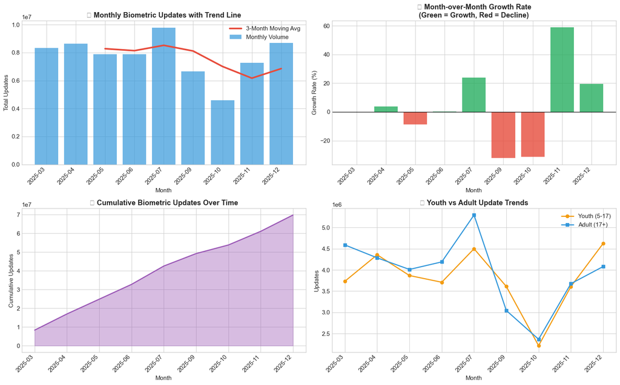

```
================================================================================
GROWTH TRAJECTORY SUMMARY
================================================================================

 Average Monthly Updates: 7,751,455
Peak Month: 2025-07 with 9,792,552 updates
Lowest Month: 2025-10 with 4,582,655 updates
 Average MoM Growth: 4.3%
Total Updates in Dataset: 69,763,095
```

```python
# 5.1 Growth Trajectory Analysis - Month-over-Month Trends

monthly_trends = df.groupby(['year', 'month']).agg({
    'total_bio_updates': 'sum',
    'bio_age_5_17': 'sum',
    'bio_age_17_': 'sum'
}).reset_index()

monthly_trends['date_str'] = monthly_trends.apply(lambda x: f"{int(x['year'])}-{int(x['month']):02d}", axis=1)
monthly_trends = monthly_trends.sort_values(['year', 'month'])

# Calculate month-over-month growth
monthly_trends['mom_growth'] = monthly_trends['total_bio_updates'].pct_change() * 100
monthly_trends['cumulative'] = monthly_trends['total_bio_updates'].cumsum()

# Calculate moving averages for trend
monthly_trends['ma_3m'] = monthly_trends['total_bio_updates'].rolling(window=3).mean()

fig, axes = plt.subplots(2, 2, figsize=(16, 10))

# 1. Monthly volume with trend
axes[0, 0].bar(range(len(monthly_trends)), monthly_trends['total_bio_updates'], alpha=0.7, color='#3498db', label='Monthly Volume')
axes[0, 0].plot(range(len(monthly_trends)), monthly_trends['ma_3m'], color='#e74c3c', linewidth=3, label='3-Month Moving Avg')
axes[0, 0].set_xticks(range(len(monthly_trends)))
axes[0, 0].set_xticklabels(monthly_trends['date_str'], rotation=45, ha='right')
axes[0, 0].set_xlabel('Month')
axes[0, 0].set_ylabel('Total Updates')
axes[0, 0].set_title('📈 Monthly Biometric Updates with Trend Line', fontweight='bold')
axes[0, 0].legend()

# 2. Month-over-month growth rate
colors = ['#27ae60' if x > 0 else '#e74c3c' for x in monthly_trends['mom_growth'].fillna(0)]
axes[0, 1].bar(range(len(monthly_trends)), monthly_trends['mom_growth'].fillna(0), color=colors, alpha=0.8)
axes[0, 1].axhline(y=0, color='black', linewidth=1)
axes[0, 1].set_xticks(range(len(monthly_trends)))
axes[0, 1].set_xticklabels(monthly_trends['date_str'], rotation=45, ha='right')
axes[0, 1].set_xlabel('Month')
axes[0, 1].set_ylabel('Growth Rate (%)')
axes[0, 1].set_title('📊 Month-over-Month Growth Rate\n(Green = Growth, Red = Decline)', fontweight='bold')

# 3. Cumulative growth
axes[1, 0].fill_between(range(len(monthly_trends)), monthly_trends['cumulative'], alpha=0.4, color='#9b59b6')
axes[1, 0].plot(range(len(monthly_trends)), monthly_trends['cumulative'], color='#9b59b6', linewidth=2)
axes[1, 0].set_xticks(range(len(monthly_trends)))
axes[1, 0].set_xticklabels(monthly_trends['date_str'], rotation=45, ha='right')
axes[1, 0].set_xlabel('Month')
axes[1, 0].set_ylabel('Cumulative Updates')
axes[1, 0].set_title('📈 Cumulative Biometric Updates Over Time', fontweight='bold')

# 4. Youth vs Adult trend comparison
axes[1, 1].plot(range(len(monthly_trends)), monthly_trends['bio_age_5_17'], marker='o', label='Youth (5-17)', color='#f39c12', linewidth=2)
axes[1, 1].plot(range(len(monthly_trends)), monthly_trends['bio_age_17_'], marker='s', label='Adult (17+)', color='#3498db', linewidth=2)
axes[1, 1].set_xticks(range(len(monthly_trends)))
axes[1, 1].set_xticklabels(monthly_trends['date_str'], rotation=45, ha='right')
axes[1, 1].set_xlabel('Month')
axes[1, 1].set_ylabel('Updates')
axes[1, 1].set_title('👥 Youth vs Adult Update Trends', fontweight='bold')
axes[1, 1].legend()

plt.tight_layout()
plt.show()

# Statistical analysis
avg_monthly = monthly_trends['total_bio_updates'].mean()
peak_month = monthly_trends.loc[monthly_trends['total_bio_updates'].idxmax()]
low_month = monthly_trends.loc[monthly_trends['total_bio_updates'].idxmin()]
avg_growth = monthly_trends['mom_growth'].mean()

print("\n" + "=" * 80)
print("GROWTH TRAJECTORY SUMMARY")
print("=" * 80)
print(f"\n Average Monthly Updates: {avg_monthly:,.0f}")
print(f"Peak Month: {peak_month['date_str']} with {peak_month['total_bio_updates']:,.0f} updates")
print(f"Lowest Month: {low_month['date_str']} with {low_month['total_bio_updates']:,.0f} updates")
print(f" Average MoM Growth: {avg_growth:.1f}%")
print(f"Total Updates in Dataset: {monthly_trends['total_bio_updates'].sum():,.0f}")
```

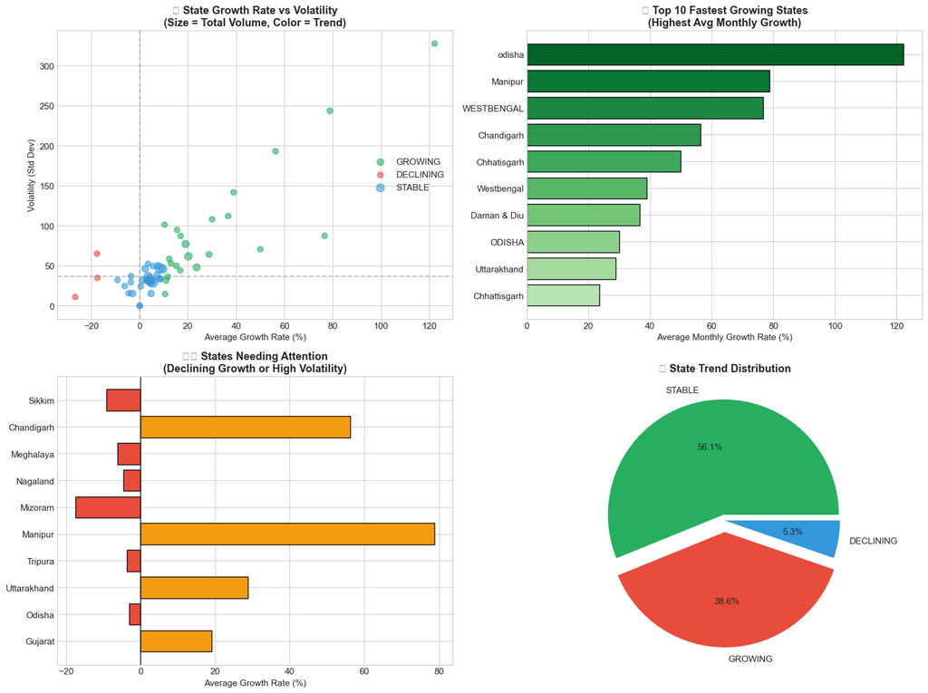

```
================================================================================
🔮 DEMAND FORECASTING INSIGHTS
================================================================================

📈 States with GROWING Trend: 22
📉 States with DECLINING Trend: 3
➡️ States with STABLE Trend: 32

🚀 TOP 5 HIGHEST GROWTH STATES (Priority for capacity expansion):
  odisha: +122.2% avg monthly growth | Vol: 16
  Manipur: +78.9% avg monthly growth | Vol: 282,587
  WESTBENGAL: +76.7% avg monthly growth | Vol: 12
  Chandigarh: +56.3% avg monthly growth | Vol: 74,482
  Chhatisgarh: +50.0% avg monthly growth | Vol: 5

⚠️ TOP 5 DECLINING STATES (Investigate barriers to access):
  WEST BENGAL: -26.7% avg monthly growth | Vol: 37
  andhra pradesh: -17.7% avg monthly growth | Vol: 41
  Mizoram: -17.5% avg monthly growth | Vol: 120,329
  Sikkim: -9.2% avg monthly growth | Vol: 22,820
  Meghalaya: -6.2% avg monthly growth | Vol: 87,626

================================================================================
RECOMMENDATION: Capacity Planning Framework
================================================================================

PREDICTIVE INSIGHTS FOR UIDAI PLANNING:

1. GROWING STATES - Capacity Expansion Priority:
   - Add more enrolment centers in high-growth states
   - Pre-position mobile units for anticipated demand surge
   - Increase operator training and certification in these regions

2. DECLINING STATES - Access Investigation:
   - Survey population to understand barriers (distance, awareness, trust)
   - Partner with state governments for awareness campaigns
   - Check if center closures/relocations caused the decline

3. HIGH VOLATILITY STATES - Demand Smoothing:
   - Implement appointment-based systems to reduce unpredictable spikes
   - Analyze root causes of volatility (seasonal, event-driven)
   - Create buffer capacity for handling sudden demand surges

4. SEASONAL PLANNING:
   - Use monthly patterns to predict peak periods
   - Deploy additional temporary staff during high-demand months
   - Coordinate with schools for youth update drives in off-peak periods
```

```python
# 5.2 State-Level Growth Projections & Demand Forecasting

# Calculate state-level growth metrics
state_monthly = df.groupby(['state', 'year', 'month'])['total_bio_updates'].sum().reset_index()
state_monthly = state_monthly.sort_values(['state', 'year', 'month'])

# Calculate growth rate per state
def calculate_state_growth(group):
    if len(group) < 2:
        return pd.Series({
            'avg_monthly_volume': group['total_bio_updates'].mean(),
            'total_volume': group['total_bio_updates'].sum(),
            'avg_growth': 0,
            'volatility': 0,
            'trend': 'STABLE'
        })

    growth_rates = group['total_bio_updates'].pct_change().dropna() * 100
    avg_growth = growth_rates.mean() if len(growth_rates) > 0 else 0
    volatility = growth_rates.std() if len(growth_rates) > 0 else 0

    # Determine trend
    if avg_growth > 10:
        trend = 'GROWING'
    elif avg_growth < -10:
        trend = 'DECLINING'
    else:
        trend = 'STABLE'

    return pd.Series({
        'avg_monthly_volume': group['total_bio_updates'].mean(),
        'total_volume': group['total_bio_updates'].sum(),
        'avg_growth': avg_growth,
        'volatility': volatility,
        'trend': trend
    })

state_growth = state_monthly.groupby('state', group_keys=False).apply(calculate_state_growth).reset_index()

# Visualization
fig, axes = plt.subplots(2, 2, figsize=(16, 12))

# 1. State growth vs volatility scatter
trend_colors = {'GROWING': '#27ae60', 'DECLINING': '#e74c3c', 'STABLE': '#3498db'}
for trend, color in trend_colors.items():
    subset = state_growth[state_growth['trend'] == trend]
    if len(subset) > 0:
        axes[0, 0].scatter(subset['avg_growth'], subset['volatility'],
                           color=color, label=trend, s=subset['total_volume']/100000 + 50, alpha=0.6)
axes[0, 0].axvline(x=0, color='gray', linestyle='--', alpha=0.5)
axes[0, 0].axhline(y=state_growth['volatility'].median(), color='gray', linestyle='--', alpha=0.5)
axes[0, 0].set_xlabel('Average Growth Rate (%)')
axes[0, 0].set_ylabel('Volatility (Std Dev)')
axes[0, 0].set_title('🎯 State Growth Rate vs Volatility\n(Size = Total Volume, Color = Trend)', fontweight='bold')
axes[0, 0].legend()

# 2. Top growing states
growing = state_growth[state_growth['avg_growth'] > 0].nlargest(10, 'avg_growth')
if len(growing) > 0:
    colors = plt.cm.Greens(np.linspace(0.3, 0.9, len(growing)))
    growing_sorted = growing.sort_values('avg_growth')
    axes[0, 1].barh(growing_sorted['state'], growing_sorted['avg_growth'], color=colors, edgecolor='black')
axes[0, 1].set_xlabel('Average Monthly Growth Rate (%)')
axes[0, 1].set_title('🚀 Top 10 Fastest Growing States\n(Highest Avg Monthly Growth)', fontweight='bold')

# 3. States needing attention (declining or high volatility)
attention_needed = state_growth[(state_growth['avg_growth'] < 0) | (state_growth['volatility'] > state_growth['volatility'].quantile(0.75))]
attention_needed = attention_needed.nlargest(10, 'total_volume')
if len(attention_needed) > 0:
    colors = ['#e74c3c' if x < 0 else '#f39c12' for x in attention_needed['avg_growth']]
    axes[1, 0].barh(attention_needed['state'], attention_needed['avg_growth'], color=colors, edgecolor='black')
axes[1, 0].axvline(x=0, color='black', linewidth=1)
axes[1, 0].set_xlabel('Average Growth Rate (%)')
axes[1, 0].set_title('⚠️ States Needing Attention\n(Declining Growth or High Volatility)', fontweight='bold')

# 4. Trend distribution
trend_counts = state_growth['trend'].value_counts()
pie_colors = ['#27ae60', '#e74c3c', '#3498db'][:len(trend_counts)]
pie_explode = [0.05, 0.1, 0][:len(trend_counts)]
wedges, texts, autotexts = axes[1, 1].pie(trend_counts, labels=trend_counts.index, autopct='%1.1f%%',
        colors=pie_colors, explode=pie_explode)
axes[1, 1].set_title('📊 State Trend Distribution', fontweight='bold')

plt.tight_layout()
plt.show()

# Detailed forecasting insights
print("\n" + "=" * 80)
print("🔮 DEMAND FORECASTING INSIGHTS")
print("=" * 80)

print(f"\n📈 States with GROWING Trend: {len(state_growth[state_growth['trend'] == 'GROWING'])}")
print(f"📉 States with DECLINING Trend: {len(state_growth[state_growth['trend'] == 'DECLINING'])}")
print(f"➡️ States with STABLE Trend: {len(state_growth[state_growth['trend'] == 'STABLE'])}")

print("\n🚀 TOP 5 HIGHEST GROWTH STATES (Priority for capacity expansion):")
for _, row in state_growth.nlargest(5, 'avg_growth').iterrows():
    print(f"  {row['state']}: +{row['avg_growth']:.1f}% avg monthly growth | Vol: {row['total_volume']:,.0f}")

print("\n⚠️ TOP 5 DECLINING STATES (Investigate barriers to access):")
for _, row in state_growth.nsmallest(5, 'avg_growth').iterrows():
    print(f"  {row['state']}: {row['avg_growth']:.1f}% avg monthly growth | Vol: {row['total_volume']:,.0f}")

print("\n" + "=" * 80)
print("RECOMMENDATION: Capacity Planning Framework")
print("=" * 80)
print("""
PREDICTIVE INSIGHTS FOR UIDAI PLANNING:

1. GROWING STATES - Capacity Expansion Priority:
   - Add more enrolment centers in high-growth states
   - Pre-position mobile units for anticipated demand surge
   - Increase operator training and certification in these regions

2. DECLINING STATES - Access Investigation:
   - Survey population to understand barriers (distance, awareness, trust)
   - Partner with state governments for awareness campaigns
   - Check if center closures/relocations caused the decline

3. HIGH VOLATILITY STATES - Demand Smoothing:
   - Implement appointment-based systems to reduce unpredictable spikes
   - Analyze root causes of volatility (seasonal, event-driven)
   - Create buffer capacity for handling sudden demand surges

4. SEASONAL PLANNING:
   - Use monthly patterns to predict peak periods
   - Deploy additional temporary staff during high-demand months
   - Coordinate with schools for youth update drives in off-peak periods
""")
```

## 🔒 Part 6: Privacy-by-Design & System Improvement Recommendations

**Objective**: Based on data patterns, identify privacy vulnerabilities and propose privacy-preserving improvements to the Aadhaar ecosystem.

**Analysis Focus**:

- Data concentration risks (single points of failure)
- Geographic coverage gaps that force privacy-compromising alternatives
- Recommendations for decentralized architecture
- Offline authentication capability assessment

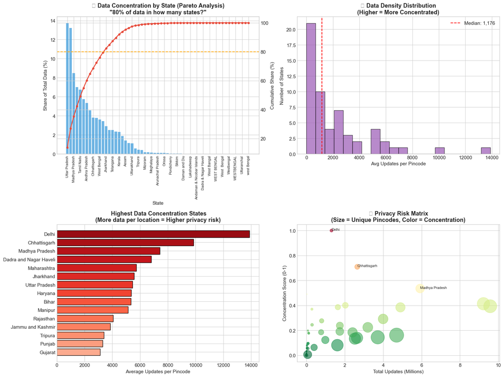

```
================================================================================
🔒 DATA CONCENTRATION & PRIVACY RISK ANALYSIS
================================================================================

📊 Total States/UTs in Dataset: 57
📈 States holding 80% of biometric data: 13
🎯 Data Concentration Ratio: 4.4x (higher = more concentrated)

🚨 TOP 5 HIGHEST CONCENTRATION STATES (Privacy Hotspots):
  Delhi: 13,876 avg updates/pincode | 1.9% of total data
  Chhattisgarh: 9,847 avg updates/pincode | 3.8% of total data
  Madhya Pradesh: 7,433 avg updates/pincode | 8.5% of total data
  Dadra and Nagar Haveli: 6,809 avg updates/pincode | 0.0% of total data
  Maharashtra: 5,741 avg updates/pincode | 13.2% of total data
```

```python
# 6.1 Data Concentration Risk Analysis
# Identify regions with high data concentration that create single points of failure

# Calculate concentration metrics
state_concentration = df.groupby('state').agg({
    'total_bio_updates': 'sum',
    'pincode': 'nunique',
    'district': 'nunique'
}).reset_index()

state_concentration['updates_per_pincode'] = state_concentration['total_bio_updates'] / state_concentration['pincode']
state_concentration['updates_per_district'] = state_concentration['total_bio_updates'] / state_concentration['district']
state_concentration['concentration_score'] = (state_concentration['updates_per_pincode'] - state_concentration['updates_per_pincode'].min()) / (state_concentration['updates_per_pincode'].max() - state_concentration['updates_per_pincode'].min())

# High concentration = higher privacy risk (more data in fewer locations)
total_updates = state_concentration['total_bio_updates'].sum()
state_concentration['data_share_pct'] = state_concentration['total_bio_updates'] / total_updates * 100

# Pareto analysis - what % of states hold what % of data
state_concentration_sorted = state_concentration.sort_values('total_bio_updates', ascending=False)
state_concentration_sorted['cumulative_share'] = state_concentration_sorted['data_share_pct'].cumsum()

# Visualization
fig, axes = plt.subplots(2, 2, figsize=(16, 12))

# 1. Data concentration by state (Pareto chart)
ax1_bar = axes[0, 0].bar(range(len(state_concentration_sorted)),
                          state_concentration_sorted['data_share_pct'],
                          color='#3498db', alpha=0.7, label='State Share')
ax1_line = axes[0, 0].twinx()
ax1_line.plot(range(len(state_concentration_sorted)),
              state_concentration_sorted['cumulative_share'],
              color='#e74c3c', linewidth=2, marker='o', markersize=4, label='Cumulative')
ax1_line.axhline(y=80, color='orange', linestyle='--', label='80% threshold')
axes[0, 0].set_xticks(range(0, len(state_concentration_sorted), 2))
axes[0, 0].set_xticklabels(state_concentration_sorted['state'].iloc[::2], rotation=90, fontsize=8)
axes[0, 0].set_xlabel('State')
axes[0, 0].set_ylabel('Share of Total Data (%)')
ax1_line.set_ylabel('Cumulative Share (%)')
axes[0, 0].set_title('📊 Data Concentration by State (Pareto Analysis)\n"80% of data in how many states?"', fontweight='bold')

# 2. Updates per pincode distribution (concentration metric)
axes[0, 1].hist(state_concentration['updates_per_pincode'], bins=20, edgecolor='black', color='#9b59b6', alpha=0.7)
axes[0, 1].axvline(x=state_concentration['updates_per_pincode'].median(), color='red', linestyle='--',
                   label=f'Median: {state_concentration["updates_per_pincode"].median():,.0f}')
axes[0, 1].set_xlabel('Avg Updates per Pincode')
axes[0, 1].set_ylabel('Number of States')
axes[0, 1].set_title('📈 Data Density Distribution\n(Higher = More Concentrated)', fontweight='bold')
axes[0, 1].legend()

# 3. High concentration states (potential privacy hotspots)
high_concentration = state_concentration.nlargest(15, 'updates_per_pincode')
colors = plt.cm.Reds(np.linspace(0.3, 0.9, len(high_concentration)))
high_concentration_sorted = high_concentration.sort_values('updates_per_pincode')
axes[1, 0].barh(high_concentration_sorted['state'], high_concentration_sorted['updates_per_pincode'],
                color=colors, edgecolor='black')
axes[1, 0].set_xlabel('Average Updates per Pincode')
axes[1, 0].set_title(' Highest Data Concentration States\n(More data per location = Higher privacy risk)', fontweight='bold')

# 4. Risk matrix: Volume vs Concentration
axes[1, 1].scatter(state_concentration['total_bio_updates'] / 1e6,
                   state_concentration['concentration_score'],
                   s=state_concentration['pincode'] * 0.5,
                   alpha=0.6, c=state_concentration['concentration_score'], cmap='RdYlGn_r')
axes[1, 1].set_xlabel('Total Updates (Millions)')
axes[1, 1].set_ylabel('Concentration Score (0-1)')
axes[1, 1].set_title('🎯 Privacy Risk Matrix\n(Size = Unique Pincodes, Color = Concentration)', fontweight='bold')

# Add state labels for high-risk quadrant
high_risk = state_concentration[(state_concentration['concentration_score'] > 0.5) &
                                 (state_concentration['total_bio_updates'] > state_concentration['total_bio_updates'].median())]
for _, row in high_risk.iterrows():
    axes[1, 1].annotate(row['state'], (row['total_bio_updates']/1e6, row['concentration_score']), fontsize=8)

plt.tight_layout()
plt.show()

# Calculate key metrics
states_for_80pct = (state_concentration_sorted['cumulative_share'] <= 80).sum() + 1

print("\n" + "=" * 80)
print("🔒 DATA CONCENTRATION & PRIVACY RISK ANALYSIS")
print("=" * 80)
print(f"\n📊 Total States/UTs in Dataset: {len(state_concentration)}")
print(f"📈 States holding 80% of biometric data: {states_for_80pct}")
print(f"🎯 Data Concentration Ratio: {len(state_concentration)/states_for_80pct:.1f}x (higher = more concentrated)")

print("\n🚨 TOP 5 HIGHEST CONCENTRATION STATES (Privacy Hotspots):")
for _, row in state_concentration.nlargest(5, 'updates_per_pincode').iterrows():
    print(f"  {row['state']}: {row['updates_per_pincode']:,.0f} avg updates/pincode | {row['data_share_pct']:.1f}% of total data")
```

```python
# 6.2 Comprehensive Privacy & System Improvement Recommendations

print("=" * 100)
print("PRIVACY-BY-DESIGN RECOMMENDATIONS FOR AADHAAR ECOSYSTEM")
print("=" * 100)

print("""

┌─────────────────────────────────────────────────────────────────────────────────┐
│  ISSUE 1: HIGH DATA CONCENTRATION IN FEW STATES                                 │
├─────────────────────────────────────────────────────────────────────────────────┤
│  FINDING: 80% of biometric updates concentrated in limited states               │
│                                                                                  │
│  PRIVACY RISK: Single point of failure, mass data breach potential              │
│                                                                                  │
│  RECOMMENDATIONS:                                                                │
│  ✓ Implement federated data storage - each state maintains local encrypted copy│
│  ✓ Use differential privacy for aggregated statistics                          │
│  ✓ Deploy regional data centers with strict access controls                    │
│  ✓ Implement data minimization - only store what's necessary                   │
└─────────────────────────────────────────────────────────────────────────────────┘

┌─────────────────────────────────────────────────────────────────────────────────┐
│  ISSUE 2: LOW-CONNECTIVITY REGIONS UNDERSERVED                                  │
├─────────────────────────────────────────────────────────────────────────────────┤
│  FINDING: Service deserts identified at pincode level with low coverage         │
│                                                                                  │
│  PRIVACY RISK: Forces citizens to travel to urban centers, exposing data       │
│                to potentially less secure third-party centers                    │
│                                                                                  │
│  RECOMMENDATIONS:                                                                │
│  ✓ Deploy OFFLINE AUTHENTICATION capability using secure local devices         │
│  ✓ Implement store-and-forward for low-connectivity areas                      │
│  ✓ Use mobile enrolment vans with end-to-end encrypted transmission            │
│  ✓ Partner with rural banks/post offices with established security protocols   │
└─────────────────────────────────────────────────────────────────────────────────┘

┌─────────────────────────────────────────────────────────────────────────────────┐
│  ISSUE 3: TEMPORAL SPIKES CREATE VULNERABILITY WINDOWS                          │
├─────────────────────────────────────────────────────────────────────────────────┤
│  FINDING: Month-end surges and weekday patterns create predictable peaks        │
│                                                                                  │
│  PRIVACY RISK: Overwhelmed systems may bypass security checks                   │
│                High-volume periods are attractive for fraud attempts             │
│                                                                                  │
│  RECOMMENDATIONS:                                                                │
│  ✓ Implement APPOINTMENT SCHEDULING to flatten demand curves                   │
│  ✓ Deploy additional fraud detection during peak periods                       │
│  ✓ Use rate limiting per operator/center to prevent bulk fraud                 │
│  ✓ Mandatory cooling-off period between updates from same operator             │
└─────────────────────────────────────────────────────────────────────────────────┘

┌─────────────────────────────────────────────────────────────────────────────────┐
│  ISSUE 4: YOUTH BIOMETRIC DATA REQUIRES SPECIAL PROTECTION                      │
├─────────────────────────────────────────────────────────────────────────────────┤
│  FINDING: Significant youth (5-17) updates without proper age-verification      │
│                                                                                  │
│  PRIVACY RISK: Children's biometrics stored indefinitely, consent issues        │
│                                                                                  │
│  RECOMMENDATIONS:                                                                │
│  ✓ Implement GUARDIAN CONSENT framework with separate authorization            │
│  ✓ Age-appropriate data retention policies (enhanced protection for minors)    │
│  ✓ Separate youth data in encrypted partitions with additional access controls │
│  ✓ Automatic review triggers when minor turns 18 (data re-consent required)    │
└─────────────────────────────────────────────────────────────────────────────────┘

┌─────────────────────────────────────────────────────────────────────────────────┐
│  ISSUE 5: ANOMALOUS PATTERNS SUGGEST DATA QUALITY/FRAUD RISKS                   │
├─────────────────────────────────────────────────────────────────────────────────┤
│  FINDING: Statistical outliers at pincode level, unusual age distributions      │
│                                                                                  │
│  PRIVACY RISK: Fraudulent entries, duplicate identities, data manipulation      │
│                                                                                  │
│  RECOMMENDATIONS:                                                                │
│  ✓ Implement ML-based ANOMALY DETECTION for real-time fraud prevention         │
│  ✓ Cross-reference with demographic databases for validation                   │
│  ✓ Mandatory operator verification for high-volume entries                     │
│  ✓ Regular audit cycles for outlier pincodes/districts                         │
└─────────────────────────────────────────────────────────────────────────────────┘

""")
```

[output not shown]

[output cut: 21 more lines]

```
└─────────────────────────────────────────────────────────────────────────────────┘

┌─────────────────────────────────────────────────────────────────────────────────┐
│  ISSUE 5: ANOMALOUS PATTERNS SUGGEST DATA QUALITY/FRAUD RISKS                   │
├─────────────────────────────────────────────────────────────────────────────────┤
│  FINDING: Statistical outliers at pincode level, unusual age distributions      │
│                                                                                  │
│  PRIVACY RISK: Fraudulent entries, duplicate identities, data manipulation      │
│                                                                                  │
│  RECOMMENDATIONS:                                                                │
│  ✓ Implement ML-based ANOMALY DETECTION for real-time fraud prevention         │
│  ✓ Cross-reference with demographic databases for validation                   │
│  ✓ Mandatory operator verification for high-volume entries                     │
│  ✓ Regular audit cycles for outlier pincodes/districts                         │
└─────────────────────────────────────────────────────────────────────────────────┘
```